### Prediction project: Exercise performance classifier

#### 2016-09-21

### Summary

We tested several prediction algorithms to predict exercise performance from data from sensors worn by users performing an exercise; subjects were instructed to perform an exercise correctly or in one of four incorrect ways. Cross-validation was used to determine model accuracy on out-of-sample data, and the execution times for the models were recorded. The boosted trees method and the k-means nearest-neighbor classification algorithms proved to be the most accurate, achieving a predicted 96% accuracy in classification on out-of-sample data. But the k-means nearest-neighbor method was substantially faster.

### Introduction

The goal of this project is to build and test a predictor for exercise data. The exercise data was obtained from “fitbit” style accelerometers worn by subjects performing a simple dumbbell bicep curl exercise. The subjects were instructed to perform the exercise correctly, or in one of four incorrect ways. (For example, one incorrect method was to not lower the dumbbell far enough.) The training dataset includes 19622 observations of 160 variables, including the class of exercise (the five classes given as A, B, C, D, or E).

For more information, see: http://groupware.les.inf.puc-rio.br/har. This site gives a paper with a more detailed discussion: Velloso, E.; Bulling, A.; Gellersen, H.; Ugulino, W.; Fuks, H. Qualitative Activity Recognition of Weight Lifting Exercises. Proceedings of 4th International Conference in Cooperation with SIGCHI (Augmented Human ’13) . Stuttgart, Germany: ACM SIGCHI, 2013.

Below, we will build several algorithms, which we will compare using cross-validation. We will also note the speed of execution of these algorithms.

But we will first load and prepare the training data for analysis.

### Load datasets

We begin by loading the data.

```r
training = read.csv("pml-training.csv")
dim(training)
```

```
## [1] 19622   160
```

### Exploring the data

We begin with a quick look at the structure of the dataset. We only show 20 of the 160 variables in the dataset.

```r
str(training, list.len=20)
```

```
'data.frame':   19622 obs. of  160 variables:
 $ X                       : int  1 2 3 4 5 6 7 8 9 10 ...
 $ user_name               : Factor w/ 6 levels "adelmo","carlitos",..: 2 2 2 2 2 2 2 2 2 2 ...
 $ raw_timestamp_part_1    : int  1323084231 1323084231 1323084231 1323084232 1323084232 1323084232 1323084232 1323084232 1323084232 1323084232 ...
 $ raw_timestamp_part_2    : int  788290 808298 820366 120339 196328 304277 368296 440390 484323 484434 ...
 $ cvtd_timestamp          : Factor w/ 20 levels "02/12/2011 13:32",..: 9 9 9 9 9 9 9 9 9 9 ...
 $ new_window              : Factor w/ 2 levels "no","yes": 1 1 1 1 1 1 1 1 1 1 ...
 $ num_window              : int  11 11 11 12 12 12 12 12 12 12 ...
 $ roll_belt               : num  1.41 1.41 1.42 1.48 1.48 1.45 1.42 1.42 1.43 1.45 ...
 $ pitch_belt              : num  8.07 8.07 8.07 8.05 8.07 8.06 8.09 8.13 8.16 8.17 ...
 $ yaw_belt                : num  -94.4 -94.4 -94.4 -94.4 -94.4 -94.4 -94.4 -94.4 -94.4 -94.4 ...
 $ total_accel_belt        : int  3 3 3 3 3 3 3 3 3 3 ...
 $ kurtosis_roll_belt      : Factor w/ 397 levels "","-0.016850",..: 1 1 1 1 1 1 1 1 1 1 ...
 $ kurtosis_picth_belt     : Factor w/ 317 levels "","-0.021887",..: 1 1 1 1 1 1 1 1 1 1 ...
 $ kurtosis_yaw_belt       : Factor w/ 2 levels "","#DIV/0!": 1 1 1 1 1 1 1 1 1 1 ...
 $ skewness_roll_belt      : Factor w/ 395 levels "","-0.003095",..: 1 1 1 1 1 1 1 1 1 1 ...
 $ skewness_roll_belt.1    : Factor w/ 338 levels "","-0.005928",..: 1 1 1 1 1 1 1 1 1 1 ...
 $ skewness_yaw_belt       : Factor w/ 2 levels "","#DIV/0!": 1 1 1 1 1 1 1 1 1 1 ...
 $ max_roll_belt           : num  NA NA NA NA NA NA NA NA NA NA ...
 $ max_picth_belt          : int  NA NA NA NA NA NA NA NA NA NA ...
 $ max_yaw_belt            : Factor w/ 68 levels "","-0.1","-0.2",..: 1 1 1 1 1 1 1 1 1 1 ...
  [list output truncated]
```

The variable to be predicted is the final variable, `classe`:

```r
head(training$classe, n=20)
```

```
 [1] A A A A A A A A A A A A A A A A A A A A
Levels: A B C D E
```

Information given at the link and paper above indicates the general structure of the training dataset. It includes variables that give raw instrumentation data, such as `roll_belt`, and some derived features or variables computed from the raw data, such as `max_roll_belt`.

The raw data was collected at a sample rate of 45 Hz, and given in “windows” of 0.5 to 2.5 sec in length. The derived features or variables are given for some of the windows; these variables are mostly composed of missing values (coded as `NA`). Here is a small plot representing a typical interval of data contained in the training dataset. (This shows 225 samples, or 5 sec, of data.)

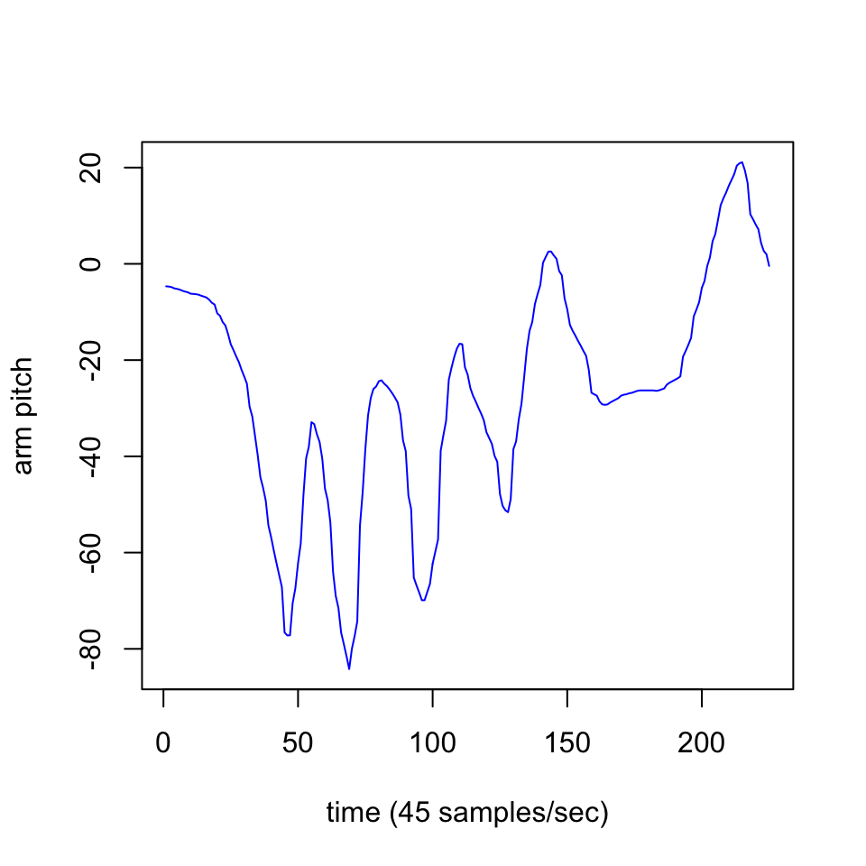

```r
ind = 251:475
x = 1:length(ind)
y = training$pitch_arm[ind]
plot(x,y, type="l", col="blue", ylab="arm pitch", xlab="time (45 samples/sec)")
```

Individual variables will show noticable differences between the exercise classes, as seen in the density plots of `pitch_arm` by exercise class. (But of course, only in the aggregate will the variables enable good classification and prediction.)

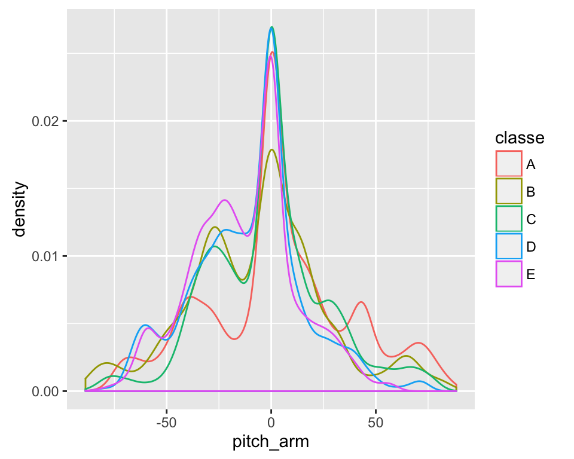

```r
library(ggplot2)
ggplot(training, aes(pitch_arm, colour = classe)) +
  geom_density()
```

### Cleaning and preprocessing the data

It might seem logical to base predictions on derived features, such as variables with names indicating that they are averages or variances of the corresponding raw instrument data variables (such as `avg_pitch_arm` for `pitch_arm`).

But as seen above, only a small fraction of the observations include these derived features (about 2% of the observations). So we must base our predictions only upon the raw instrument data, because test data will be unlikely to include values for those features. So here, we clean the data to remove all columns containing missing values (or the code `#DIV/0!`).

```r
vector.is.bad = function(v) {
    if (length(v) > length(v[!is.na(v)]))
        return(TRUE)
    v = as.character(v) # assuming u is a factor to begin with
    n = length(v)
    vector.bad = FALSE
    for (i in 1:n) {
        if (!is.na(v[i])) {
           if (v[i]=="#DIV/0!" | v[i]=="")
                vector.bad = TRUE
        }
    }
    return(vector.bad)
}

nc <- ncol(training)
bad.ind <- c()
for (i in 1:nc) {
    if (vector.is.bad(training[,i]))
        bad.ind <- c(bad.ind, i)
}
training.clean <- training[,-bad.ind]
# str(training.clean)
```

This leaves 60 variables.

Now we scale and center the data, so that statistical learning algorithms will treat all variables alike. We also discard the first 7 variables, which are features not expected to have predictive value (such as timestamps or window “numbers”). This leaves 52 variables to base predictions on.

```r
ind = 8:59
for (i in ind) {
    m <- mean(training.clean[,i])
    s <- sd(training.clean[,i])
    training.clean[,i] <- (training.clean[,i] - m)/s
}
```

### Model selection

Here, we do quick preliminary calculations, to try get a sense of what prediction models are likely to perform best. To do this, we take a single random sample of 1000 observations for a ‘little’ training set, and a single random sample of 1000 observations for a ‘little’ testing set. We fit the model to the little training set, and find the accuracy against the little testing set. This is an inadequate method of validating a model of course, and only using a small portion of the training set will likely yield a model with weaker performance. But this will guide us to the model(s) meriting full attention.

```r
k <- nrow(training.clean)
ind <- sample(1:k,2000,replace=FALSE)
ind1 <- ind[1:1000]
ind2 <- ind[1001:2000]
col.ind <- 8:60 # drop factor variables at beginning of table
little.training <- training.clean[ind1,col.ind]
little.testing <- training.clean[ind2,col.ind]
training.clean <- training.clean[,col.ind]
dim(training.clean)
```

```
## [1] 19622    53
```

```r
library(caret)
set.seed(6457)
```

#### Linear discriminant analysis

We begin with a linear discriminant analysis classifier. We profile the code using the `system.time` function. (This has the limitation of not computing the time spent on the actual calculations, performed by C code “under the hood.” But the elapsed time should reflect how much time the calculation took.)

```r
system.time({
    mod.lda = train(classe ~ ., data=little.training, method="lda")
})
```

```
   user  system elapsed
  1.491   0.089   1.580
```

```r
pred.lda = predict(mod.lda, little.testing)
confusionMatrix(pred.lda, little.testing$classe)
```

```
Confusion Matrix and Statistics

          Reference
Prediction   A   B   C   D   E
         A 214  21  25  14   3
         B  12 133  17   8  22
         C  19  22 115  14  17
         D  21   4  26 125  26
         E   0  17   5   4 116

Overall Statistics

               Accuracy : 0.703
                 95% CI : (0.6736, 0.7312)
    No Information Rate : 0.266
    P-Value [Acc > NIR] : < 2.2e-16

                  Kappa : 0.6259
 Mcnemar's Test P-Value : 6.723e-05

Statistics by Class:

                     Class: A Class: B Class: C Class: D Class: E
Sensitivity            0.8045   0.6751   0.6117   0.7576   0.6304
Specificity            0.9142   0.9265   0.9113   0.9078   0.9681
Pos Pred Value         0.7726   0.6927   0.6150   0.6188   0.8169
Neg Pred Value         0.9281   0.9208   0.9102   0.9499   0.9207
Prevalence             0.2660   0.1970   0.1880   0.1650   0.1840
Detection Rate         0.2140   0.1330   0.1150   0.1250   0.1160
Detection Prevalence   0.2770   0.1920   0.1870   0.2020   0.1420
Balanced Accuracy      0.8593   0.8008   0.7615   0.8327   0.7993
```

This yields an accuracy of about 0.7, and it took about 1.5 seconds.

#### Decision tree

A decision tree model yields poor results (only 0.357 accuracy rate), but fairly fast (3 seconds). We do not show the calculations here (and we’ve edited out the `system.time` function call for clarity).

```r
mod.rpart = train(classe ~ ., data=little.training, method="rpart")
pred.rpart = predict(mod.rpart, little.testing)
confusionMatrix(pred.rpart, little.testing$classe)
```

#### Boosting

We obtain much better results with boosting (the `gbm` model): about 90% accuracy. However, the method is much slower: about 100 elapsed seconds.

```r
mod.gbm = train(classe ~ ., data=little.training, method="gbm",
                verbose=FALSE)
pred.gbm = predict(mod.gbm, little.testing)
confusionMatrix(pred.gbm, little.testing$classe)
```

#### Random forest

We now try a random forest model. This is slightly more accurate than the boosting model, at 92%. But it is considerably slower: 250 seconds.

```r
mod.rf <- train(classe ~ ., data=little.training, method="rf", prox=TRUE)
pred.rf <- predict(mod.rf, newdata=little.testing[,-53])
confusionMatrix(pred.rf, little.testing$classe)
```

#### KNN classifier

Finally, we try a k-means nearest-neighbor (or KNN) classifier. This is fast: about 4 seconds elapsed. But its accuracy is about 72% on this calculation; not as accurate tree-based methods (random forest or boosting). However, it was only tested here on only about 5% of the whole training set. We will perform cross-validation on this method below, and see much higher accuracy.

```r
mod.knn <- train(classe ~ ., data=little.training, method="knn")
pred.knn <- predict(mod.knn, newdata=little.testing[,-53])
confusionMatrix(pred.knn, little.testing$classe)
```

### Model Validation

Here, we will use k-fold cross-validation to test our final two models. One of these will be boosting, which we have seen above is very accurate and perhaps not prohibitively slow. The other will be the KNN classifier, which is very fast.

We use the `train` function in the `caret` library, which automatically will try different parameters for these methods. Thus we will both build the model–select good values for tuning parameters–as well as validate them.

#### Boosting

We begin with boosting.

```r
system.time({
    mod.gbm.cv = train(classe ~ ., data=training.clean,
                       method="gbm", verbose=FALSE,
                       trControl=trainControl(method="cv",number=5))
})
```

```
   user  system elapsed
376.322   2.765 379.139
```

```r
print(mod.gbm.cv)
```

```
Stochastic Gradient Boosting

19622 samples
   52 predictor
    5 classes: 'A', 'B', 'C', 'D', 'E'

No pre-processing
Resampling: Cross-Validated (5 fold)
Summary of sample sizes: 15696, 15698, 15698, 15698, 15698
Resampling results across tuning parameters:

  interaction.depth  n.trees  Accuracy   Kappa
  1                   50      0.7512488  0.6845903
  1                  100      0.8230557  0.7760429
  1                  150      0.8539904  0.8152160
  2                   50      0.8530220  0.8137363
  2                  100      0.9068901  0.8821490
  2                  150      0.9333906  0.9157060
  3                   50      0.8970539  0.8696587
  3                  100      0.9438893  0.9289916
  3                  150      0.9635105  0.9538332

Tuning parameter 'shrinkage' was held constant at a value of 0.1

Tuning parameter 'n.minobsinnode' was held constant at a value of 10
Accuracy was used to select the optimal model using  the largest value.
The final values used for the model were n.trees = 150,
 interaction.depth = 3, shrinkage = 0.1 and n.minobsinnode = 10.
```

We see strong results: The cross-validation predicts a 96% accuracy rate on out-of-sample observations, if the tuning parameters are chosen to be `interaction.depth = 3` and `n.trees = 150`. But the calculation is fairly slow at about 379 seconds.

By the way, I attempted to perform this cross-validation for random forests. I had reason to believe it would take more than 5000 seconds. Unfortunately, an error or bug caused the code to crash after a calculation of about that long (an hour and a half).

#### KNN classifier

We conclude with the KNN classifier.

```r
system.time({
    mod.knn.cv = train(classe ~ ., data=training.clean,
                       method="knn",
                       trControl=trainControl(method="cv",number=5))
})
```

```
   user  system elapsed
160.314   0.356 160.725
```

```r
print(mod.knn.cv)
```

```
k-Nearest Neighbors

19622 samples
   52 predictor
    5 classes: 'A', 'B', 'C', 'D', 'E'

No pre-processing
Resampling: Cross-Validated (5 fold)
Summary of sample sizes: 15696, 15698, 15698, 15698, 15698
Resampling results across tuning parameters:

  k  Accuracy   Kappa
  5  0.9724290  0.9651201
  7  0.9626441  0.9527351
  9  0.9519925  0.9392505

Accuracy was used to select the optimal model using  the largest value.
The final value used for the model was k = 5.
```

Note the accuracy is high; 97%, much higher than seen in our preliminary calculations for model selection performed on a small subset of the training data. But the `train` function has also determined the best choice for the parameter `k`, namely 5 centers. And this model is clearly faster than the boosting model; the tuning and cross-validation performed by `train` took 160 seconds.

### Conclusion

Based on our investigation, a good solution for the exercise classification problem appears to be the KNN classifier. With a tuning parameter of `k = 5` centers, it is very accurate—97% accurate in cross-validation. We can expect similar performance on out-of-sample data. It is also faster than tree-based methods of similar accuracy, such as the boosting method examined above.